# Labor Force Survey Analysis For Istanbul

#### Following plots and analyses can be made with the datasset.

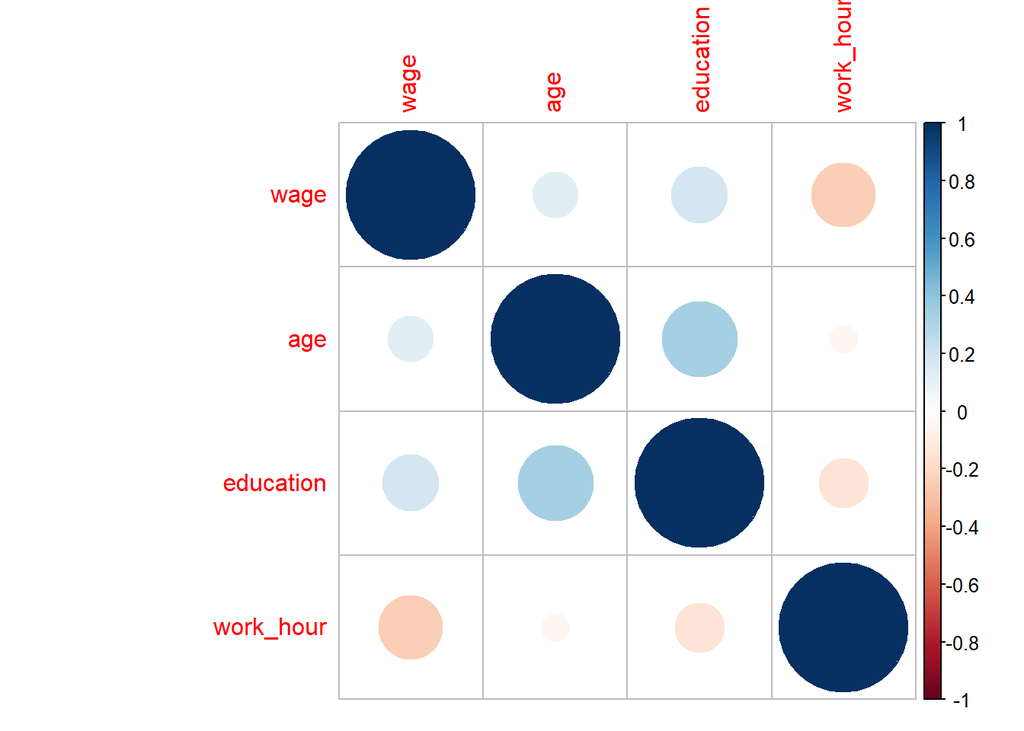

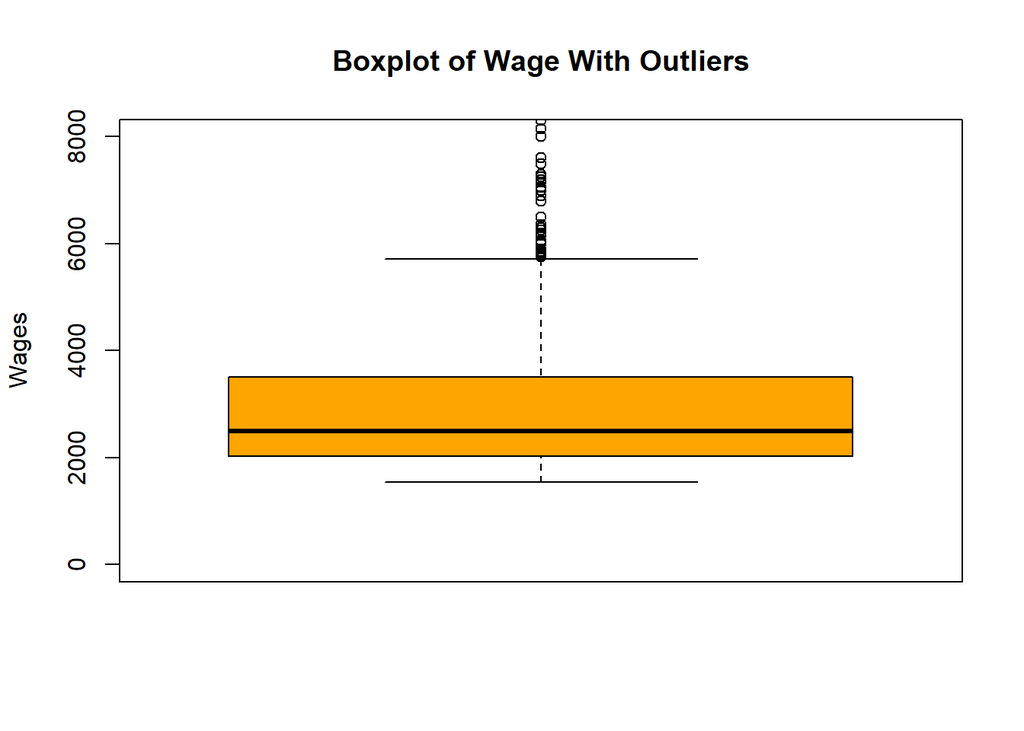

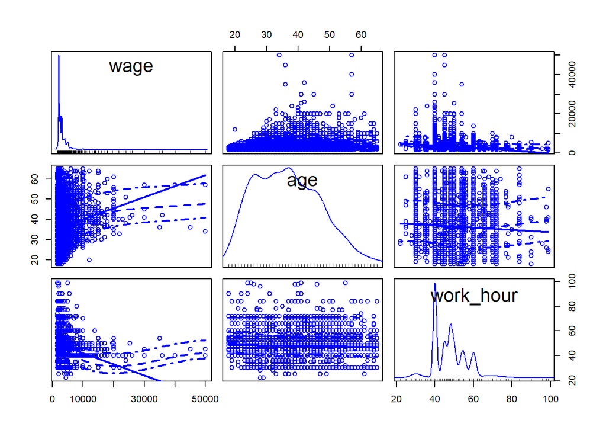

From this plot it can be interpret that wage is highly right skewed distribution, while constructing our linear model it will be good for us to take the log of wage since we know it is highly skewed.

### Question 1 Answer:

To estimate a wage equation we can use “male”,“age”, “education”, and “work_hour”.

**We construct a multiple regression model in order to determine the relationship between our dependent and independent variables.**

```r
S(wage.mod)
```

```
## Call: lm(formula = wage ~ male + age + education + work_hour, data = datas)
##
## Coefficients:
##             Estimate Std. Error t value Pr(>|t|)
## (Intercept) 4435.691    166.180  26.692  < 2e-16 ***
## male         296.773     48.136   6.165 7.29e-10 ***
## age           14.067      2.235   6.294 3.21e-10 ***
## education     89.327      6.437  13.878  < 2e-16 ***
## work_hour    -63.766      2.596 -24.566  < 2e-16 ***
## ---
## Signif. codes:  0 '***' 0.001 '**' 0.01 '*' 0.05 '.' 0.1 ' ' 1
##
## Residual standard deviation: 2247 on 10689 degrees of freedom
## Multiple R-squared: 0.0907
## F-statistic: 266.5 on 4 and 10689 DF,  p-value: < 2.2e-16
##      AIC      BIC
## 195409.3 195453.0
```

*wage.mod does not have the log transformation on wage.*

[output not shown]

```r
coef(wage.mod2)
```

```
##  (Intercept)         male          age    education    work_hour
## 11.993649034  0.119491029  0.003010517  0.029771848 -0.022430187
```

```r
S(wage.mod2)
```

```
## Call: lm(formula = log2(wage) ~ male + age + education + work_hour, data =
##          datas)
##
## Coefficients:
##               Estimate Std. Error t value Pr(>|t|)
## (Intercept) 11.9936490  0.0434378 276.111  < 2e-16 ***
## male         0.1194910  0.0125824   9.497  < 2e-16 ***
## age          0.0030105  0.0005842   5.153  2.6e-07 ***
## education    0.0297718  0.0016824  17.696  < 2e-16 ***
## work_hour   -0.0224302  0.0006785 -33.059  < 2e-16 ***
## ---
## Signif. codes:  0 '***' 0.001 '**' 0.01 '*' 0.05 '.' 0.1 ' ' 1
##
## Residual standard deviation: 0.5872 on 10689 degrees of freedom
## Multiple R-squared: 0.1414
## F-statistic: 440.2 on 4 and 10689 DF,  p-value: < 2.2e-16
##      AIC      BIC
## 18969.07 19012.73
```

*wage.mod2 has log transformation of wage.*

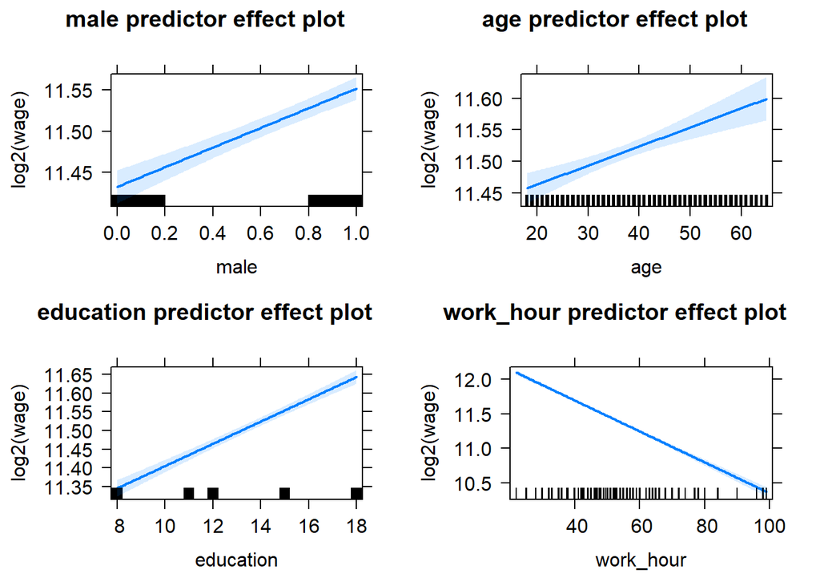

We can visualize what we estimated in our regression model with predictor effect plots. As we can see with more working hour wager has a less wage, and as education level increases wage increases too.